# Computational Biologist

Nathan Angell

During the summer of 2021, I had the opportunity to get involved with the [Summer Undergraduate Research Fellowship (SURF) program](https://web.uri.edu/rinsfepscor/surf/). I worked under [Professor Weicksel](https://departments.bryant.edu/science-and-technology/faculty/weicksel-steven) with my colleague Jarrod Dube and a couple other key members. My background is in data science but I wanted to combine the fields of data science and science because I believe that innovation comes through learning different subjects.

Our goal was to learn about science and being able to create a data pipeline that was able to identify Chromatin Regulatory Loops.

We first started off with conducting research in the lab. The genome is structured in a 3D way consisting of chromatin loops. The problem that we realized is that many of the details that control and regulate these chromatin loops are not understood.

So, we experimented with the process of 4C, Circular Chromosome Confirmation Capture, to map the chromatin loops in the Zebrafish embryos genome. We also used pipetts for the transportation of a specific amount of liquid.

The 4C process creates a lot of data that are not generally organized. So, we created a data pipeline that organizes and gets rid of unwanted data.

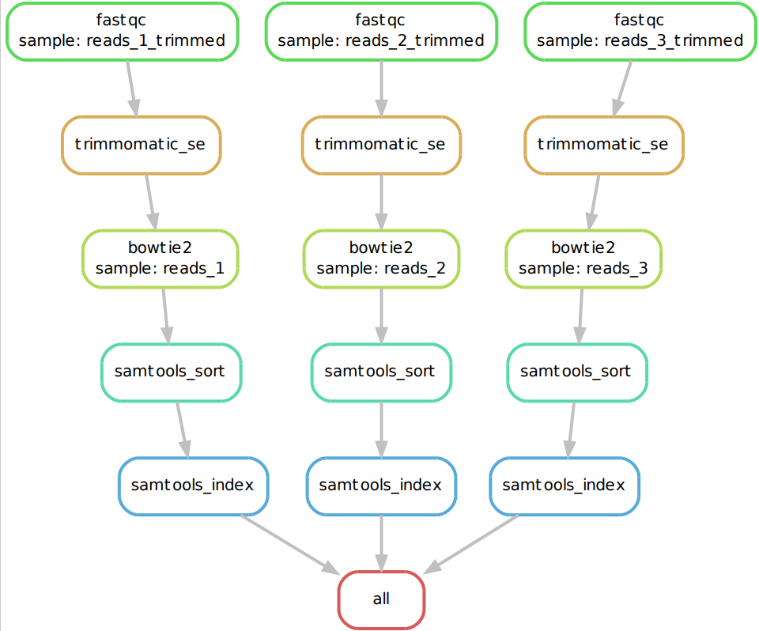

We then added an additional step that would entail us to use a subset of Deep learning called Convolutional Neural Networks (CNN). That would identify supplemental chromatin connections within the 3D genome.